# Block 5: Connection of higher temperature and GPP

Author

Rebecca Franke

Published

November 27, 2026

# Libraries

```r
getwd()
```

```
[1] "C:/Users/Becky/Documents/3_Semester/Environmental Modelling/datascience_env_monit"
```

```r
# General stuff I need often
library(readr)
library(dplyr)
library(readr)
library(ggplot2)
library(tidyr)
library(stringr)
library(knitr)
library(lubridate)
```

# Links to my github

```r
#https://github.com/rf158/datascience_env_monit/tree/main/reports
#https://github.com/rf158/datascience_env_monit/tree/main/scripts
```

# Data prep

```r
# 10_annual_table.R: one row per tower-year, ready for analysis
# Run AFTER 09_merge.R. Output: data/processed/site_annual.csv

source(file.path("scripts", "block5", "block5_sites.R"))
```

```
==> Your towers:
 site_id igbp country       lat         lon first_year last_year
  GF-Guy  EBF      GF   5.27870  -52.924800       2004      2025
  US-GLE  ENF      US  41.36650 -106.239900       2005      2020
  BE-Vie   MF      BE  50.30496    5.998099       1996      2026
  AU-Ync  GRA      AU -34.98780  146.290800       2012      2025
  JP-Mse  CRO      JP  36.05393  140.026930       2002      2009
```

```r
# ---- Settings -----------------------------------------------------------------
min_days  <- 350   # minimum days with data per tower-year (flux variables)
min_modis <- 3     # minimum good 16-day EVI values in the summer season

daily  <- read_csv(file.path("data", "processed", "site_daily.csv"),  show_col_types = FALSE)
static <- read_csv(file.path("data", "processed", "site_static.csv"), show_col_types = FALSE)
vi     <- read_csv(file.path("data", "external", "modis", "modis_vi_my_sites.csv"),
                   show_col_types = FALSE)

# ---- 1. Annual flux values per tower-year ---------------------------------------
# TA_F: degC | P_F: mm/day -> sum = mm/yr | GPP: gC m-2 d-1 -> sum = gC m-2 yr-1
annual <- daily |>
  mutate(year = year(date)) |>
  group_by(site_id, year) |>
  summarise(n_days_TA  = sum(!is.na(TA_F)),
            n_days_P   = sum(!is.na(P_F)),
            n_days_GPP = sum(!is.na(GPP_NT_VUT_REF)),
            TA_year    = mean(TA_F, na.rm = TRUE),
            P_year     = sum(P_F, na.rm = TRUE),
            GPP_year   = sum(GPP_NT_VUT_REF, na.rm = TRUE),
            .groups = "drop")

# ---- 2. Quality: drop incomplete years (nothing is filled) ----------------------
message("Dropped tower-years (incomplete):")
print(as.data.frame(filter(annual, n_days_TA < min_days | n_days_P < min_days |
                             n_days_GPP < min_days)))
```

```
   site_id year n_days_TA n_days_P n_days_GPP    TA_year   P_year   GPP_year
1   AU-Ync 2012       366      366         85 16.4903607  631.744   28.81478
2   AU-Ync 2016       366      366        295 17.3841776 1112.432  749.58569
3   AU-Ync 2023       365      365          0 16.6689589  364.000    0.00000
4   AU-Ync 2025       365      365        275 17.3879178  221.177  173.67846
5   BE-Vie 1996       366      366        169  6.5120410  710.566  758.81626
6   BE-Vie 2009       365      365        325  8.5737370  939.000 1848.13021
7   BE-Vie 2023       365      365        341  9.6894027 1218.345 1996.27033
8   BE-Vie 2026       234      234        234 11.1006197  510.032 1467.24152
9   GF-Guy 2004       366      366          0 25.7151995 2756.000    0.00000
10  GF-Guy 2005       365      365          0 25.8830767 3072.200    0.00000
11  GF-Guy 2006       365      365          0 25.5213370 3509.600    0.00000
12  GF-Guy 2007       365      365          0 25.5931644 3550.480    0.00000
13  GF-Guy 2008       366      366          0 25.5113470 2838.000    0.00000
14  GF-Guy 2009       365      365          0 25.6279425 3123.800    0.00000
```

[output cut: 18 more lines]

```r
annual <- filter(annual, n_days_TA >= min_days, n_days_P >= min_days, n_days_GPP >= min_days)

# ---- 3. WorldClim normals and anomalies -----------------------------------------
annual <- annual |>
  left_join(select(static, site_id, lat, BIO1, BIO12), by = "site_id") |>
  mutate(dT     = TA_year - BIO1,            # degC; > 0 = warmer than 1970-2000
         dP     = P_year  - BIO12,           # mm;   > 0 = wetter than 1970-2000
         dP_pct = 100 * dP / BIO12) |>
  group_by(site_id) |>
  mutate(dGPP = GPP_year - mean(GPP_year)) |> # GPP has no normal: tower's own mean
  ungroup()

# ---- 4. MODIS: peak EVI and summer EVI from the original 16-day values ----------
# Summer = Jun-Aug (northern hemisphere) or Dec-Feb (southern; Dec counts to next year)
evi_year <- vi |>
  filter(!is.na(evi)) |>
  left_join(select(static, site_id, lat), by = "site_id") |>
  mutate(year  = year(date),
         month = month(date),
         in_summer   = if_else(lat >= 0, month %in% 6:8, month %in% c(12, 1, 2)),
         season_year = if_else(lat < 0 & month == 12, year + 1L, year)) |>
  group_by(site_id, year) |>
  summarise(EVI_max = max(evi), n_evi = n(), .groups = "drop") |>
  left_join(
    vi |>
      filter(!is.na(evi)) |>
      left_join(select(static, site_id, lat), by = "site_id") |>
      mutate(month = month(date),
             in_summer = if_else(lat >= 0, month %in% 6:8, month %in% c(12, 1, 2)),
             year = if_else(lat < 0 & month == 12, year(date) + 1L, year(date))) |>
      filter(in_summer) |>
      group_by(site_id, year) |>
      summarise(EVI_summer = mean(evi), n_summer = n(), .groups = "drop"),
    by = c("site_id", "year")) |>
  mutate(EVI_summer = if_else(n_summer >= min_modis, EVI_summer, NA_real_))

annual <- left_join(annual, evi_year, by = c("site_id", "year"))  # NA where no MODIS

# ---- 5. Checks -------------------------------------------------------------------
message("\nTower-years kept per tower:");  print(table(annual$site_id))
```

```
AU-Ync BE-Vie JP-Mse US-GLE
    10     27      8     14
```

```r
message("\nTower-years with EVI:");        print(table(annual$site_id[!is.na(annual$EVI_max)]))
```

```
AU-Ync BE-Vie JP-Mse US-GLE
     6      6      8      7
```

```r
message("\nSummary of dT (are all years warmer than the normal?):"); print(summary(annual$dT))
```

```
   Min. 1st Qu.  Median    Mean 3rd Qu.    Max.
-1.6228 -0.3180  0.1860  0.2423  0.7572  1.8936
```

```r
message("\nSummary of dP_pct:");           print(summary(annual$dP_pct))
```

```
   Min. 1st Qu.  Median    Mean 3rd Qu.    Max.
 -61.03  -20.24   15.72   78.95  169.39  384.27
```

```r
stopifnot(!anyDuplicated(annual[, c("site_id", "year")]))  # one row per tower-year

write_csv(annual, file.path("data", "processed", "site_annual.csv"))
message("\nsite_annual.csv: ", nrow(annual), " tower-years")
```

# E1. Question and hypothesis

Question: How far is each tower year’s mean temperature and precipitation from the WorldClim 1970-2000 normal (BIO1, BIO12)?

Hypothesis: All tower years will be warmer than the normal, and within each tower, the years with the larger warm anomaly will have lower annual GPP, because heat increases water loss and makes plants close their stomata, which reduces carbon uptake. The ecological reason is that heat raises evaporative demand, plants close their stomata to limit water loss, and carbon uptake falls.

Datasets: WorldClim (BIO1 as the temperature normal) and MODIS EVI as the second dataset, to check whether the canopy shows the same pattern as GPP.

The five towers cover very different ecosystems and climates. Each tower is compared only with its own other years, which removes differences between sites and vegetation types. BE-Vie has a long record (27 usable years), but JP-Mse (8 years) and AU-Ync (10 years) are short, so their slopes are uncertain. GF-Guy could not be analysed because it has no night-time-partitioned GPP, which leaves four towers. The WorldClim normal is a 9 km grid cell for 1970-2000, so the anomaly includes a site offset, and a relationship between temperature and GPP shows an association, not a cause. MODIS EVI, a satellite measure of canopy greenness, serves as a second, independent description of each tower’s canopy and is available for 6 to 8 years per tower (27 tower-years in total), so it only supports a descriptive check of whether peak greenness moves in the same direction as GPP.

# E2. Data

A provenance table, one row per dataset (FLUXNET plus your two).

```r
options(knitr.kable.NA = "–")
```

## Provenance table

```r
prov <- data.frame(
  Dataset = c("FLUXNET (daily files, FLUXMET_DD)",
              "WorldClim 2.1",
              "MODIS MOD13Q1 (Collection 6.1)"),
  `Variables used` = c(
    "TA_F (°C), P_F (mm d-1), GPP_NT_VUT_REF (g C m-2 d-1)",
    "BIO1 (annual mean temperature, °C), BIO12 (annual precipitation, mm)",
    "Red, NIR and blue reflectance and pixel reliability; EVI computed from them"),
  `Spatial resolution` = c(
    "Point measurement (tower footprint)",
    "5 arc-minutes (about 9 km)",
    "250 m pixels, 9 x 9 pixel window (about 2 x 2 km) around the tower"),
  `Time resolution and period` = c(
    "Daily, aggregated to years. Tower records: AU-Ync 2012-2025, BE-Vie 1996-2026, JP-Mse 2002-2009, US-GLE 2005-2020",
    "Long-term normal 1970-2000, one value per tower",
    "16-day composites, last 8 years of each tower record"),
  `Downloaded on` = c("13.11.26", "26.11.26", "26.11.26"),
  `Script and changes` = c(
    "09_merge.R (-9999 read as NA); 10_annual_table.R (years with < 350 days dropped; annual mean TA_F, sums of P_F and GPP). GF-Guy excluded: GPP_NT_VUT_REF empty",
    "02_worldclim.R, res_min = 5. Anomaly dT = annual mean TA_F minus BIO1 (10_annual_table.R)",
    "08_modis_ndvi_evi.R: years_back changed from 3 to 8, GF-Guy skipped; only pixel reliability 0 and 1 kept"),
  Citation = c(
    "Pastorello et al. (2020), Scientific Data 7, 225, https://doi.org/10.1038/s41597-020-0534-3",
    "Fick, S.E. & Hijmans, R.J. (2017) WorldClim 2. Int. J. Climatol. 37, 4302–4315. https://doi.org/10.1002/joc.5086",
    "Didan, K. (2021) MOD13Q1 MODIS/Terra Vegetation Indices 16-Day L3 Global 250m SIN Grid V061. NASA LP DAAC. https://doi.org/10.5067/MODIS/MOD13Q1.061"),
  check.names = FALSE)
kable(prov)
```

Table 1: Provenance of the three datasets.

| Dataset | Variables used | Spatial resolution | Time resolution and period | Downloaded on | Script and changes | Citation |
| --- | --- | --- | --- | --- | --- | --- |
| FLUXNET (daily files, FLUXMET_DD) | TA_F (°C), P_F (mm d-1), GPP_NT_VUT_REF (g C m-2 d-1) | Point measurement (tower footprint) | Daily, aggregated to years. Tower records: AU-Ync 2012-2025, BE-Vie 1996-2026, JP-Mse 2002-2009, US-GLE 2005-2020 | 13.11.26 | 09_merge.R (-9999 read as NA); 10_annual_table.R (years with < 350 days dropped; annual mean TA_F, sums of P_F and GPP). GF-Guy excluded: GPP_NT_VUT_REF empty | Pastorello et al. (2020), Scientific Data 7, 225, https://doi.org/10.1038/s41597-020-0534-3 |
| WorldClim 2.1 | BIO1 (annual mean temperature, °C), BIO12 (annual precipitation, mm) | 5 arc-minutes (about 9 km) | Long-term normal 1970-2000, one value per tower | 26.11.26 | 02_worldclim.R, res_min = 5. Anomaly dT = annual mean TA_F minus BIO1 (10_annual_table.R) | Fick, S.E. & Hijmans, R.J. (2017) WorldClim 2. Int. J. Climatol. 37, 4302–4315. https://doi.org/10.1002/joc.5086 |
| MODIS MOD13Q1 (Collection 6.1) | Red, NIR and blue reflectance and pixel reliability; EVI computed from them | 250 m pixels, 9 x 9 pixel window (about 2 x 2 km) around the tower | 16-day composites, last 8 years of each tower record | 26.11.26 | 08_modis_ndvi_evi.R: years_back changed from 3 to 8, GF-Guy skipped; only pixel reliability 0 and 1 kept | Didan, K. (2021) MOD13Q1 MODIS/Terra Vegetation Indices 16-Day L3 Global 250m SIN Grid V061. NASA LP DAAC. https://doi.org/10.5067/MODIS/MOD13Q1.061 |

## Description of the datasets at the towers

```r
daily  <- read_csv("data/processed/site_daily.csv",  show_col_types = FALSE)
static <- read_csv("data/processed/site_static.csv", show_col_types = FALSE)
annual <- read_csv("data/processed/site_annual.csv", show_col_types = FALSE)
vi     <- read_csv("data/external/modis/modis_vi_my_sites.csv", show_col_types = FALSE)

clim <- daily |>
  mutate(year = year(date)) |>
  group_by(site_id, year) |>
  summarise(n_TA = sum(!is.na(TA_F)), n_P = sum(!is.na(P_F)),
            TA = mean(TA_F, na.rm = TRUE), P = sum(P_F, na.rm = TRUE), .groups = "drop") |>
  filter(n_TA >= 350, n_P >= 350) |>
  group_by(site_id) |>
  summarise(`Years` = n(), `Measured T (°C)` = mean(TA), `Measured P (mm/yr)` = mean(P))

modis <- vi |>
  filter(!is.na(evi)) |>
  group_by(site_id) |>
  summarise(`MODIS from` = format(min(date)), `MODIS to` = format(max(date)),
            `Composites` = n(), `Mean EVI` = mean(evi), `Peak EVI` = max(evi))

evi_years <- annual |> filter(!is.na(EVI_max)) |> count(site_id, name = "Years with EVI (analysis)")

d4 <- static |>
  select(site_id, Type = igbp, `BIO1 (°C)` = BIO1, `BIO12 (mm/yr)` = BIO12) |>
  left_join(clim,      by = "site_id") |>
  left_join(modis,     by = "site_id") |>
  left_join(evi_years, by = "site_id") |>
  mutate(`Measured P (mm/yr)` = if_else(site_id == "JP-Mse", NA_real_, `Measured P (mm/yr)`)) |>
  rename(Tower = site_id)

kable(d4, digits = 1)
```

Table 2: WorldClim normals (1970-2000) compared with the tower’s measured climate, and MODIS EVI per tower. Measured precipitation at JP-Mse is not shown because its P_F values are implausible (annual sums 4583-6392 mm). GF-Guy: no MODIS data downloaded.

| Tower | Type | BIO1 (°C) | BIO12 (mm/yr) | Years | Measured T (°C) | Measured P (mm/yr) | MODIS from | MODIS to | Composites | Mean EVI | Peak EVI | Years with EVI (analysis) |
| --- | --- | --- | --- | --- | --- | --- | --- | --- | --- | --- | --- | --- |
| GF-Guy | EBF | 25.8 | 2822 | 22 | 25.8 | 3170.7 | – | – | – | – | – | – |
| US-GLE | ENF | 0.7 | 496 | 16 | 0.3 | 1350.9 | 2013-02-18 | 2020-12-18 | 113 | 0.2 | 0.3 | 7 |
| BE-Vie | MF | 8.0 | 1087 | 30 | 8.6 | 935.7 | 2019-01-17 | 2026-11-01 | 161 | 0.4 | 0.7 | 6 |
| AU-Ync | GRA | 16.6 | 435 | 14 | 17.1 | 525.1 | 2018-01-01 | 2025-12-19 | 183 | 0.2 | 0.5 | 6 |
| JP-Mse | CRO | 14.2 | 1320 | 8 | 13.8 | – | 2002-01-01 | 2009-12-19 | 177 | 0.2 | 0.6 | 8 |

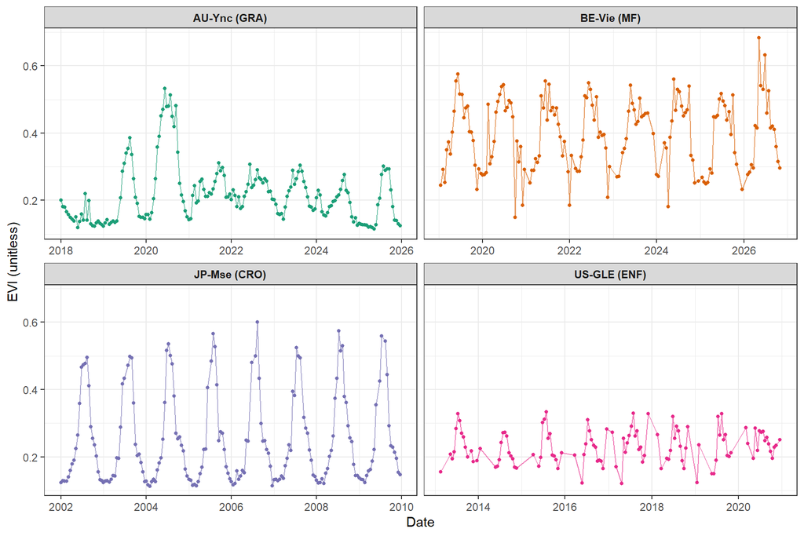

Figure 1: MODIS EVI (unitless) at the towers. Each point is one 16-day composite (MOD13Q1, 250 m): the mean EVI of good-quality pixels in a 9 x 9 pixel window around the tower. Higher values mean a denser, greener canopy. Only the last 8 years of each record were downloaded.

```r
vi_plot <- vi |>
  filter(!is.na(evi)) |>
  left_join(select(static, site_id, igbp), by = "site_id") |>
  mutate(panel = paste0(site_id, " (", igbp, ")"))

ggplot(vi_plot, aes(date, evi, colour = site_id)) +
  geom_line(linewidth = 0.4, alpha = 0.6) +
  geom_point(size = 1) +
  facet_wrap(~ panel, scales = "free_x", ncol = 2) +
  scale_colour_brewer(palette = "Dark2") +
  labs(x = "Date", y = "EVI (unitless)") +
  theme_bw(base_size = 11) +
  theme(legend.position = "none", strip.text = element_text(face = "bold"))
```

# E3. Methods

Describe what you did, in enough detail that a classmate could repeat it:

Download: which scripts, which settings, what you changed and why, what failed and how you solved it. Extraction: how each dataset was matched to the tower (nearest cell, window around the tower, point service) and in which coordinate system. Processing: units and conversions, quality filters, aggregation to a common time step, how you joined the tables, how you treated missing values. Analysis: what you computed to test the question, and on which n.

## Download

I used FLUXNET daily files (FLUXMET_DD) from the Block 4 zip files in data/raw. WorldClim 2.1 was downloaded with the provided script 02_worldclim.R without changes (bioclimatic variables at 5 arc-minutes, about 9 km, via the geodata package) on 26.11.26. MODIS MOD13Q1 was downloaded with 08_modis_ndvi_evi.R. The first run used the default years_back <- 3. After merging, only 8 tower-years had EVI together with complete flux data, which was too few for a comparison within a tower. I therefore deleted the pixel files and ran the script again with years_back <- 8 and with GF-Guy skipped (sites <- sites[sites$site_id != “GF-Guy”, ]), because GF-Guy has no usable GPP (see Processing). The download took longer than expected and had to be repeated, because there was too much happening on the server, so there was no code problem. The line with leaving Guyana out was added before the second run.

## Extraction

WorldClim values were extracted with terra::extract() at each tower’s longitude and latitude (EPSG:4326), which returns the value of the 5-arc-minute cell that contains the tower. For MODIS, the ORNL DAAC subset service (via the MODISTools package) was queried with the tower’s latitude and longitude. It returned a window of 9 × 9 pixels of 250 m (about 2 × 2 km, km_lr = km_ab = 1) around the tower.

## Processing

In FLUXNET, −9999 was read as NA when the files were read in 09_merge.R. MODIS fill values (−1000 and below) were set to NA and the reflectances scaled by 0.0001. No missing value was filled by hand or copied from another tower. Units: air temperature TA_F in °C, precipitation P_F in mm per day, and GPP (GPP_NT_VUT_REF) in g C m⁻² d⁻¹. For MODIS, I kept only pixels with reliability 0 or 1, calculated EVI per pixel as 2.5 · (NIR − Red) / (NIR + 6 · Red − 7.5 · Blue + 1), and averaged it over the good pixels of each date.

The coarsest common time step for my question is one year. In 10_annual_table.R, I aggregated the daily data to annual mean temperature, annual precipitation and annual GPP (sum of the daily values), and dropped every tower-year with fewer than 350 days of data. Annual EVI values (peak EVI, and a summer mean that needs at least 3 composites) come from the original 16-day values, not from the daily interpolation created in 09_merge.R. Tables were joined by site_id (static table) and by site_id and date or year (time series). The WorldClim normals (BIO1, BIO12) were attached to each tower-year by site_id.

GF-Guy was excluded from the analysis, because its night-time-partitioned GPP (GPP_NT_VUT_REF) is empty. A daytime-partitioned column (GPP_DT_VUT_REF) exists, but I did not use it, so that all towers rest on the same partitioning method. This leaves four towers. Measured precipitation at JP-Mse is implausible (annual sums of 4583 to 6392 mm and up to 427 mm in one day, compared with a WorldClim normal of 1320 mm), so I did not interpret it. I did not do a deep search into why because this was not the main focus here. Missing days were not filled. Annual GPP is the sum over the days with data, so years with gaps (at most 15 days, since years with fewer than 350 days were dropped) may be up to about 4% too low.

## Analysis

I calculated the temperature anomaly dT for each tower-year as annual mean TA_F minus BIO1, and the GPP anomaly dGPP as annual GPP minus the tower’s own mean over the years used. For each tower, I fitted a linear regression of annual GPP on dT and report the slope (g C m⁻² yr⁻¹ per °C) and the Pearson correlation r. The numbers of years are 10 (AU-Ync), 27 (BE-Vie), 8 (JP-Mse) and 14 (US-GLE), which makes 59 tower-years from four towers. MODIS EVI is available for 6, 6, 8 and 7 of these years (27 in total). For MODIS, I used the annual peak EVI (the highest 16-day composite of the year) as a measure of maximum canopy greenness, and compared it with the temperature anomaly dT within each tower. This rests on 6, 6, 8 and 7 years (AU-Ync, BE-Vie, JP-Mse, US-GLE; 27 in total) and is used descriptively, not as a second test.

# E4. Results

Your figure(s) and the summary number from Part D, each with a caption that a reader understands without the text.

## Question analysis

```r
annual <- read.csv("data/processed/site_annual.csv")
static <- read.csv("data/processed/site_static.csv")

# ---- Numbers per tower (for D2 and D3) ----------------------------------------
stats <- annual |>
  left_join(select(static, site_id, igbp), by = "site_id") |>
  group_by(site_id, igbp) |>
  summarise(n        = n(),
            mean_dT  = mean(dT),                                    # °C vs 1970-2000 normal
            r        = cor(dT, dGPP),                               # Pearson correlation
            slope    = unname(coef(lm(GPP_year ~ dT))[2]),          # g C m-2 yr-1 per °C
            p        = summary(lm(GPP_year ~ dT))$coefficients[2, 4],
            .groups = "drop") |>
  mutate(label = sprintf("%s (%s)\nn = %d years | slope = %.0f g C m-2 yr-1 per °C (r = %.2f)",
                       site_id, igbp, n, slope, r))
print(as.data.frame(stats), digits = 3)
```

```
  site_id igbp  n mean_dT      r  slope        p
1  AU-Ync  GRA 10   0.604 -0.952 -428.6 2.22e-05
2  BE-Vie   MF 27   0.652  0.164   36.3 4.15e-01
3  JP-Mse  CRO  8  -0.411  0.779   97.7 2.26e-02
4  US-GLE  ENF 14  -0.434  0.587  123.8 2.73e-02
                                                                      label
1 AU-Ync (GRA)\nn = 10 years | slope = -429 g C m-2 yr-1 per °C (r = -0.95)
2     BE-Vie (MF)\nn = 27 years | slope = 36 g C m-2 yr-1 per °C (r = 0.16)
3     JP-Mse (CRO)\nn = 8 years | slope = 98 g C m-2 yr-1 per °C (r = 0.78)
4   US-GLE (ENF)\nn = 14 years | slope = 124 g C m-2 yr-1 per °C (r = 0.59)
```

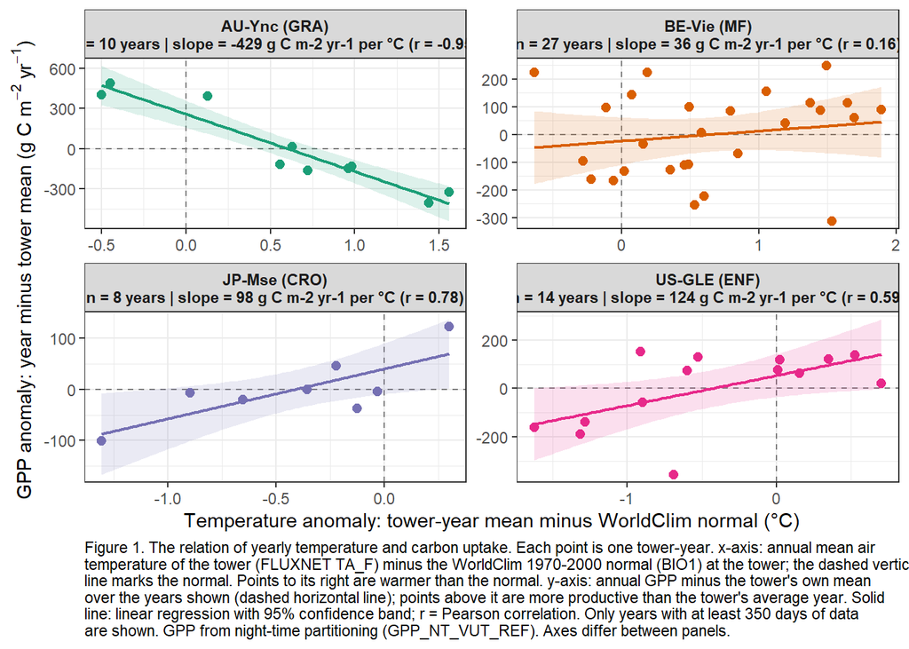

```r
plot_df <- left_join(annual, select(stats, site_id, label), by = "site_id")

# ---- Figure -------------------------------------------------------------------
cap <- paste(strwrap(paste(
  "Figure 1. The relation of yearly temperature and carbon uptake. Each point is one tower-year.",
  "x-axis: annual mean air temperature of the tower (FLUXNET TA_F) minus the WorldClim 1970-2000",
  "normal (BIO1) at the tower; the dashed vertical line marks the normal. Points to its right are",
  "warmer than the normal.",
  "y-axis: annual GPP minus the tower's own mean over the years shown (dashed horizontal line);",
  "points above it are more productive than the tower's average year.",
  "Solid line: linear regression with 95% confidence band; r = Pearson correlation.",
  "Only years with at least 350 days of data are shown. GPP from night-time partitioning",
  "(GPP_NT_VUT_REF). Axes differ between panels."), width = 120), collapse = "\n")

p <- ggplot(plot_df, aes(dT, dGPP, colour = site_id, fill = site_id)) +
  geom_hline(yintercept = 0, linetype = "dashed", colour = "grey50") +
  geom_vline(xintercept = 0, linetype = "dashed", colour = "grey50") +
  geom_smooth(method = "lm", se = TRUE, alpha = 0.15, linewidth = 0.8) +
  geom_point(size = 2.2) +
  facet_wrap(~ label, scales = "free", ncol = 2) +
  scale_colour_brewer(palette = "Dark2") +
  scale_fill_brewer(palette = "Dark2") +
  labs(x = "Temperature anomaly: tower-year mean minus WorldClim normal (°C)",
       y = expression("GPP anomaly: year minus tower mean (g C"~m^-2~yr^-1*")"),
       caption = cap) +
  theme_bw(base_size = 11) +
  theme(legend.position = "none",
        strip.text = element_text(face = "bold"),
        plot.caption = element_text(hjust = 0, size = 8.5))

#dir.create("figures", showWarnings = FALSE)
#ggsave("figures/fig1_dT_vs_dGPP.png", p, width = 9, height = 8, dpi = 300)
p
```

Add the slope as your one number. It answers “how much does GPP change per °C warmer than normal?” and its unit is g C m⁻² yr⁻¹ per °C. Keep r next to it. In your code, replace the mutate(label = …) line in the stats block with this

```r
annual <- read.csv("data/processed/site_annual.csv")
table(annual$site_id)                       # years per tower
```

```
AU-Ync BE-Vie JP-Mse US-GLE
    10     27      8     14
```

```r
nrow(annual)                                # total tower-years
```

```
[1] 59
```

```r
length(unique(annual$site_id))              # number of towers
```

```
[1] 4
```

```r
table(annual$site_id[!is.na(annual$EVI_max)])   # years with EVI
```

```
AU-Ync BE-Vie JP-Mse US-GLE
     6      6      8      7
```

## MODIS

```r
daily  <- read_csv("data/processed/site_daily.csv",  show_col_types = FALSE)
static <- read_csv("data/processed/site_static.csv", show_col_types = FALSE)
annual <- read_csv("data/processed/site_annual.csv", show_col_types = FALSE)
vi     <- read_csv("data/external/modis/modis_vi_my_sites.csv", show_col_types = FALSE)

# ---- Table: WorldClim vs. measured climate, and MODIS EVI, per tower --------------
# Measured climate from all complete years (>= 350 days), all five towers
clim <- daily |>
  mutate(year = year(date)) |>
  group_by(site_id, year) |>
  summarise(n_TA = sum(!is.na(TA_F)), n_P = sum(!is.na(P_F)),
            TA = mean(TA_F, na.rm = TRUE), P = sum(P_F, na.rm = TRUE), .groups = "drop") |>
  filter(n_TA >= 350, n_P >= 350) |>
  group_by(site_id) |>
  summarise(years_clim = n(), TA_measured = mean(TA), P_measured = mean(P))

# MODIS description from the original 16-day values (towers that were downloaded)
modis <- vi |>
  filter(!is.na(evi)) |>
  group_by(site_id) |>
  summarise(MODIS_from = format(min(date)), MODIS_to = format(max(date)),
            n_composites = n(), EVI_mean = mean(evi), EVI_max = max(evi))

# Years that went into the analysis with EVI (from the annual table)
evi_years <- annual |> filter(!is.na(EVI_max)) |> count(site_id, name = "years_EVI_analysis")

table_d4 <- static |>
  select(site_id, igbp, BIO1, BIO12) |>
  left_join(clim,      by = "site_id") |>
  left_join(modis,     by = "site_id") |>
  left_join(evi_years, by = "site_id") |>
  mutate(across(where(is.numeric), ~ round(.x, 2)))

print(as.data.frame(table_d4))
```

```
  site_id igbp  BIO1 BIO12 years_clim TA_measured P_measured MODIS_from
1  GF-Guy  EBF 25.80  2822         22       25.83    3170.71       <NA>
2  US-GLE  ENF  0.66   496         16        0.26    1350.92 2013-02-18
3  BE-Vie   MF  8.00  1087         30        8.61     935.65 2019-01-17
4  AU-Ync  GRA 16.59   435         14       17.13     525.07 2018-01-01
5  JP-Mse  CRO 14.22  1320          8       13.81    5331.15 2002-01-01
    MODIS_to n_composites EVI_mean EVI_max years_EVI_analysis
1       <NA>           NA       NA      NA                 NA
2 2020-12-18          113     0.23    0.33                  7
3 2026-11-01          161     0.40    0.68                  6
4 2025-12-19          183     0.22    0.53                  6
5 2009-12-19          177     0.25    0.60                  8
```

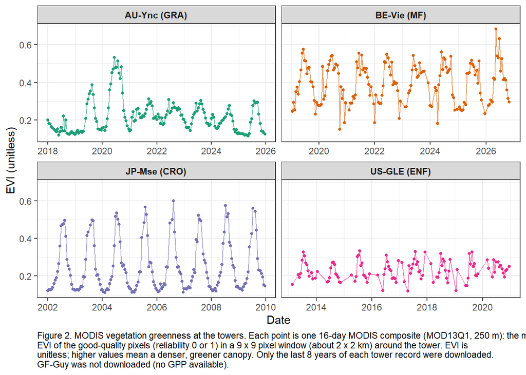

```r
#write_csv(table_d4, "data/processed/table_d4_datasets.csv")

# ---- Figure: EVI time series per tower (16-day values) ---------------------------
cap <- paste(strwrap(paste(
  "Figure 2. MODIS vegetation greenness at the towers.",
  "Each point is one 16-day MODIS composite (MOD13Q1, 250 m): the mean EVI of the good-quality",
  "pixels (reliability 0 or 1) in a 9 x 9 pixel window (about 2 x 2 km) around the tower.",
  "EVI is unitless; higher values mean a denser, greener canopy.",
  "Only the last 8 years of each tower record were downloaded. GF-Guy was not downloaded",
  "(no GPP available)."), width = 120), collapse = "\n")

vi_plot <- vi |>
  filter(!is.na(evi)) |>
  left_join(select(static, site_id, igbp), by = "site_id") |>
  mutate(panel = paste0(site_id, " (", igbp, ")"))

p2 <- ggplot(vi_plot, aes(date, evi, colour = site_id)) +
  geom_line(linewidth = 0.4, alpha = 0.6) +
  geom_point(size = 1) +
  facet_wrap(~ panel, scales = "free_x", ncol = 2) +
  scale_colour_brewer(palette = "Dark2") +
  labs(x = "Date", y = "EVI (unitless)", caption = cap) +
  theme_bw(base_size = 11) +
  theme(legend.position = "none",
        strip.text = element_text(face = "bold"),
        plot.caption = element_text(hjust = 0, size = 8.5))

#dir.create("figures", showWarnings = FALSE)
#ggsave("figures/fig2_modis_evi.png", p2, width = 9, height = 6, dpi = 300)
p2
```

## Checking precipitation:

```r
daily <- read.csv("data/processed/site_daily.csv")
jp <- daily |> filter(site_id == "JP-Mse")

# a) Daily values: what does a typical day look like?
summary(jp$P_F)                      # units should be mm per day
```

```
   Min. 1st Qu.  Median    Mean 3rd Qu.    Max.
  0.000   0.009   1.279  14.596  11.580 427.088
```

```r
mean(jp$P_F, na.rm = TRUE)           # 1320 mm/yr would be about 3.6 mm/day
```

```
[1] 14.59589
```

```r
sum(jp$P_F > 100, na.rm = TRUE)      # days with more than 100 mm (should be very few)
```

```
[1] 84
```

```r
sum(jp$P_F > 0,   na.rm = TRUE) / sum(!is.na(jp$P_F))   # share of rainy days
```

```
[1] 0.7891855
```

```r
# b) Annual totals per year: stable or jumping around?
jp |>
  mutate(year = as.integer(substr(date, 1, 4))) |>
  group_by(year) |>
  summarise(P_year = sum(P_F, na.rm = TRUE), max_day = max(P_F, na.rm = TRUE))
```

```
# A tibble: 8 × 3
   year P_year max_day
  <int>  <dbl>   <dbl>
1  2002  4695.    226.
2  2003  6392.    303.
3  2004  5496.    377.
4  2005  4583.    249.
5  2006  5956.    427.
6  2007  4849.    367.
7  2008  5164.    245.
8  2009  5514.    243.
```

```r
# c) Compare with the raw FLUXNET file: is the unit or gap-filling flag odd?

zip_file <- list.files("data/raw", pattern = "JP-Mse.*FLUXNET.*\\.zip$", full.names = TRUE)
dd <- grep("FLUXMET_DD", unzip(zip_file, list = TRUE)$Name, value = TRUE)[1]
x  <- read_csv(unz(zip_file, dd), na = c("-9999", "-9999.0"), show_col_types = FALSE)
summary(x[, intersect(c("P", "P_F", "P_F_QC"), names(x))])
```

```
      P_F              P_F_QC
 Min.   :  0.000   Min.   :0
 1st Qu.:  0.009   1st Qu.:0
 Median :  1.279   Median :0
 Mean   : 14.596   Mean   :0
 3rd Qu.: 11.580   3rd Qu.:0
 Max.   :427.088   Max.   :0
```

Why the JP-Mse precipitation is not credible

Daily values: the mean is 14.6 mm/day, and the median is 1.3 mm/day. Real rainfall at a site with a 1320 mm normal averages about 3.6 mm/day. Extremes: 84 days exceed 100 mm, and the maximum is 427 mm in a single day. That is far beyond what is plausible for one day. Annual totals: 4583 to 6392 mm in every one of the 8 years. A consistent offset of about 4 times the normal points to a measurement or unit problem in the source file, not to wet years. P_F_QC is 0 everywhere: this flag means the values were not gap-filled. So the numbers are what the file itself contains, and the problem is not something the merge or annual code introduced. Therefore, the precipitation from Japan will be excluded from interpretation.

## Supporting numbers

```r
library(dplyr)
annual <- read.csv("data/processed/site_annual.csv")
daily  <- read.csv("data/processed/site_daily.csv")
vi     <- read.csv("data/external/modis/modis_vi_my_sites.csv")
vi$date <- as.Date(vi$date)

# Anomalies, warmest/coolest year, temperature vs. precipitation, GPP trend
annual |>
  group_by(site_id) |>
  summarise(min_dT = min(dT), max_dT = max(dT),
            year_warmest = year[which.max(dT)], dGPP_warmest = dGPP[which.max(dT)],
            year_coolest = year[which.min(dT)], dGPP_coolest = dGPP[which.min(dT)],
            r_dT_P = cor(dT, P_year),        # JP-Mse: P_F implausible, ignore
            r_year_GPP = cor(year, GPP_year))
```

```
# A tibble: 4 × 9
  site_id min_dT max_dT year_warmest dGPP_warmest year_coolest dGPP_coolest
  <chr>    <dbl>  <dbl>        <int>        <dbl>        <int>        <dbl>
1 AU-Ync  -0.499  1.56          2019       -326.          2022         401.
2 BE-Vie  -0.635  1.89          2022         88.8         2010         224.
3 JP-Mse  -1.30   0.300         2004        122.          2003        -102.
4 US-GLE  -1.62   0.703         2012         21.5         2008        -160.
# ℹ 2 more variables: r_dT_P <dbl>, r_year_GPP <dbl>
```

```r
# Sensitivity check: does a shared time trend change the dT slope?
annual |>
  group_by(site_id) |>
  summarise(r_year_dT = cor(year, dT),
            slope_dT_adj = coef(lm(GPP_year ~ dT + year))["dT"])
```

```
# A tibble: 4 × 3
  site_id r_year_dT slope_dT_adj
  <chr>       <dbl>        <dbl>
1 AU-Ync     -0.499       -448.
2 BE-Vie      0.662        -97.2
3 JP-Mse      0.247         95.3
4 US-GLE      0.370        101.
```

```r
# EVI vs. temperature and GPP (6-8 years per tower)
annual |>
  filter(!is.na(EVI_max)) |>
  group_by(site_id) |>
  summarise(n = n(), r_dT_EVImax = cor(dT, EVI_max), r_GPP_EVImax = cor(GPP_year, EVI_max))
```

```
# A tibble: 4 × 4
  site_id     n r_dT_EVImax r_GPP_EVImax
  <chr>   <int>       <dbl>        <dbl>
1 AU-Ync      6     -0.162         0.411
2 BE-Vie      6     -0.260        -0.165
3 JP-Mse      8      0.0528        0.324
4 US-GLE      7      0.251         0.130
```

```r
# MODIS composites kept after the reliability filter
vi |>
  group_by(site_id) |>
  summarise(kept = n(),
            expected = round(as.numeric(max(date) - min(date)) / 16) + 1,
            pct_kept = round(100 * kept / expected),
            median_good_pixels = median(n_good_pixels))
```

```
# A tibble: 4 × 5
  site_id  kept expected pct_kept median_good_pixels
  <chr>   <int>    <dbl>    <dbl>              <int>
1 AU-Ync    183      183      100                 81
2 BE-Vie    161      179       90                 81
3 JP-Mse    177      183       97                 81
4 US-GLE    113      180       63                 81
```

```r
table(vi$site_id, format(vi$date, "%m"))
```

```
         01 02 03 04 05 06 07 08 09 10 11 12
  AU-Ync 16 16 16 16 15 16 16 16 16 10 14 16
  BE-Vie  8 13 15 16 16 16 16 16 16 10 10  9
  JP-Mse 16 16 16 16 16 13 13 15 16 10 14 16
  US-GLE  2  4  5  2 12 16 16 16 16  9 10  5
```

```r
# JP-Mse precipitation check
jp <- daily |> filter(site_id == "JP-Mse")
summary(jp$P_F)
```

```
   Min. 1st Qu.  Median    Mean 3rd Qu.    Max.
  0.000   0.009   1.279  14.596  11.580 427.088
```

```r
sum(jp$P_F > 100, na.rm = TRUE)
```

```
[1] 84
```

```r
jp |> mutate(year = as.integer(substr(date, 1, 4))) |>
  group_by(year) |> summarise(P_year = sum(P_F, na.rm = TRUE), max_day = max(P_F, na.rm = TRUE))
```

```
# A tibble: 8 × 3
   year P_year max_day
  <int>  <dbl>   <dbl>
1  2002  4695.    226.
2  2003  6392.    303.
3  2004  5496.    377.
4  2005  4583.    249.
5  2006  5956.    427.
6  2007  4849.    367.
7  2008  5164.    245.
8  2009  5514.    243.
```

# E5. Discussion

5–10 sentences:

State that you left out precipitation because the measured precipitation and the WorldClim BIO12 differ too strongly at some towers, and give the two numbers above as the reason. The first part (“all years warmer”) will not hold everywhere, since the mean anomaly was negative at JP-Mse and US-GLE. Report that as it is. State that the analysis has 4 towers, not 5, because GF-Guy has no night-time GPP.

Does the result support your hypothesis? For which towers, and for which not? Scale: for each of your two datasets, compare the pixel size with the flux footprint (about 100 m – 1 km). What does the mismatch mean for your answer? The two most important limitations (data, n, method), and what you would do with more time or more data.

# E6. Data and citation

Each FLUXNET site citation (from your snapshot), Pastorello et al. (2020), Scientific Data 7, 225, the citations of your two datasets (in the header of each script and on the Block 5 slide “How to cite what you used”), and the FLUXNET acknowledgement from flux4student/README.md.

## Site data

The data come from the FLUXNET data hub (snapshot `fluxnet_shuttle_snapshot_20261113T105747.csv`). The data citations for the five sites are:

```r
snapshot <- read.csv("data/snapshots/fluxnet_shuttle_snapshot_20261113T105747.csv")

my_sites <- c("US-GLE", "BE-Vie", "GF-Guy", "JP-Mse", "AU-Ync")

# Check that all sites exist in the snapshot
setdiff(my_sites, snapshot$site_id)
```

```
character(0)
```

```r
citations <- snapshot |>
  filter(site_id %in% my_sites) |>
  # team_member_* columns repeat rows per person, so drop them before de-duplicating
  select(site_id, product_citation) |>
  distinct() |>
  arrange(site_id)

citations
```

```
  site_id
1  AU-Ync
2  BE-Vie
3  GF-Guy
4  JP-Mse
5  US-GLE
                                                                                                                                                                                                                                                                                                            …
1                                                                                                                                                                                                     Beringer, J., Walker, J. (2026): Yanco FLUXNET Release 2026_r1 . Version 2026_r1. Terrestrial Ecosyste…
2 Vincke, C., Bogaerts, G., Chebbi, W., Chopin, H., Clément, T., De Ligne, A., Demoulin, L., Douxfils, B., Engelmann, T., Faurès, A., Heinesch, B., Hoang, K., Manise, T., Orgun, A., Piret, A., Thyrion, T. (2026). Fluxnet Archive Product from Vielsalm, 1996-01-01–2026-09-06, FLUXNET, https://hdl.hand…
3                                                                                                                                                                                     Bonal, D., Brechet, L., Burban, B. (2026). Fluxnet Archive Product from Guyaflux, 2004–2025, FLUXNET, https://hdl.hand…
4                                                                                                                                                                                        Iwata, H., Ono, K. (2026). Fluxnet Archive Product from Mase rice paddy field, 2002–2009, FLUXNET, https://hdl.hand…
5                                                                                                                                                                  John Frank, George Valentine, Bill Massman (2026), AmeriFlux FLUXNET-1F US-GLE GLEES, Ver. v1.3_r1 (2005-2020), AmeriFlux AMP, (Dataset).…
```

## FLUXNET data product

Pastorello et al. (2020), Scientific Data 7, 225, https://doi.org/10.1038/s41597-020-0534-3

## External datasets

Didan, K. (2021) MOD13Q1 MODIS/Terra Vegetation Indices 16-Day L3 Global 250m SIN Grid V061. NASA LP DAAC. https://doi.org/10.5067/MODIS/MOD13Q1.061 Fick, S.E. & Hijmans, R.J. (2017) WorldClim 2. Int. J. Climatol. 37, 4302–4315. https://doi.org/10.1002/joc.5086

## Acknowledgement

FLUXNET data products were produced and harmonized by eddy covariance regional networks and data processing centers, including AmeriFlux, ChinaFlux, European Fluxes Database, ICOS, JapanFlux, KoFlux, OzFlux, SAEON, and TERN. These products also include a modified version of ERA5 hourly data provided by the Copernicus Climate Change Service.